# Определение перспективного тарифа для телеком-компании.

## Описание проекта.

«Мегалайн» — федеральный оператор сотовой связи. Клиентам предлагают два тарифных плана:

**Тариф «Смарт»**

- Ежемесячная плата: 550 рублей
- Включено 500 минут разговора, 50 сообщений и 15 Гб интернет-трафика
- Стоимость услуг сверх тарифного пакета:
  - минута разговора: 3 рубля
  - сообщение: 3 рубля
  - 1 Гб интернет-трафика: 200 рублей

**Тариф «Ультра»**

- Ежемесячная плата: 1950 рублей
- Включено 3000 минут разговора, 1000 сообщений и 30 Гб интернет-трафика
- Стоимость услуг сверх тарифного пакета:
  - минута разговора: 1 рубль
  - сообщение: 1 рубль
  - 1 Гб интернет-трафика: 150 рублей

Примечание «Мегалайн» всегда округляет секунды до минут, а мегабайты — до гигабайт. Каждый звонок округляется отдельно: даже если он длился всего 1 секунду, будет засчитан как 1 минута. Для веб-трафика отдельные сессии не считаются. Вместо этого общая сумма за месяц округляется в бо́льшую сторону. Если абонент использует 1025 мегабайт в этом месяце, с него возьмут плату за 2 гигабайта. Неиспользованные за предыдущий месяц звонки, смс, интернет на следующий месяц не переносятся.

**Заказчик**: коммерческий департамент. **Цель исследования**: определить, какой тариф приносит больше денег, для корректировки рекламного бюджета.

Для достижения поставленой цели решим следующие **задачи**:

- Возьмем выборку из 500 пользователей "Мегалайна".
- Проведем обзор и предобработку данных: приведем данные к нужным типам, исправим ошибки.
- Изучим пользователей: кто они, откуда, каким тарифом пользуются, сколько звонков и сообщений каждый отправил за 2018 год.
- Опишем поведение клиентов оператора.
- Проверим гипотезы:
  - средняя выручка пользователей тарифов «Ультра» и «Смарт» различаются;
  - средняя выручка пользователей из Москвы отличается от выручки пользователей из других регионов.
- Сформулируем выводы.

## Обзор данных.

Импортируем все необходимые бибилиотеки.

```python
import pandas as pd
import numpy as np
import scipy.stats as st
import os
import matplotlib.pyplot as plt


pd.options.display.float_format = '{:.2f}'.format
```

Прочитаем файлы и сохраним их в переменной df_. Предусмотрим чтение файла из локального хранилища и из облака Яндекс. Выведем на экран 10 первых строк.

```python
def read_file(file, number):
    '''Функция обзора данных.
       file - имя файла в формате 'xxxx.csv'
       number - целое число.
       Считывает файл из облака Яндекс.Практикума или из домашнего каталога с ноутбуком.
       Выводит на экран number-строк датафрейма и общую информацию о количестве строк и типах данных.
    '''

    if os.path.exists('----' + file): # проверка наличия файла в облаке
        df = pd.read_csv('----' + file) # чтение файла с данными и сохранение
    else:
        try:
            df = pd.read_csv(file)
        except:
            display('Проверьте наличие файла на локальном хранилище!')

    display(df.head(number))
    print()
    display(df.info())
    print()

    # подсчет уникальных значений по столбцу и вывод их на экран (если количество не превышает 100)
    for col in df.columns:
        print( col, df[col].nunique())
        if df[col].nunique() < 100:
            print(df[col].sort_values().unique())
        print()

    print('Количество дубликатов', df.duplicated().sum())

    shape = df.shape

    return df, shape
```

```python
df_tariffs, shape_tariffs = read_file('----.csv', 5)
```

|  | messages_included | mb_per_month_included | minutes_included | rub_monthly_fee | rub_per_gb | rub_per_message | rub_per_minute | tariff_name |
| --- | --- | --- | --- | --- | --- | --- | --- | --- |
| 0 | 50 | 15360 | 500 | 550 | 200 | 3 | 3 | smart |
| 1 | 1000 | 30720 | 3000 | 1950 | 150 | 1 | 1 | ultra |

```
<class 'pandas.core.frame.DataFrame'>
RangeIndex: 2 entries, 0 to 1
Data columns (total 8 columns):
 #   Column                 Non-Null Count  Dtype
---  ------                 --------------  -----
 0   messages_included      2 non-null      int64
 1   mb_per_month_included  2 non-null      int64
 2   minutes_included       2 non-null      int64
 3   rub_monthly_fee        2 non-null      int64
 4   rub_per_gb             2 non-null      int64
 5   rub_per_message        2 non-null      int64
 6   rub_per_minute         2 non-null      int64
 7   tariff_name            2 non-null      object
dtypes: int64(7), object(1)
memory usage: 256.0+ bytes
```

```
None
```

```
messages_included 2
[  50 1000]

mb_per_month_included 2
[15360 30720]

minutes_included 2
[ 500 3000]

rub_monthly_fee 2
[ 550 1950]

rub_per_gb 2
[150 200]

rub_per_message 2
[1 3]

rub_per_minute 2
[1 3]

tariff_name 2
['smart' 'ultra']

Количество дубликатов 0
```

Информация о тарифах:

- `tariff_name` — название тарифа
- `rub_monthly_fee` — ежемесячная абонентская плата в рублях
- `minutes_included` — количество минут разговора в месяц, включённых в абонентскую плату
- `messages_included` — количество сообщений в месяц, включённых в абонентскую плату
- `mb_per_month_included` — объём интернет-трафика, включённого в абонентскую плату (в мегабайтах)
- `rub_per_minute` — стоимость минуты разговора сверх тарифного пакета (например, если в тарифе 100 минут разговора в месяц, то со 101 минуты будет взиматься плата)
- `rub_per_message` — стоимость отправки сообщения сверх тарифного пакета
- `rub_per_gb` — стоимость дополнительного гигабайта интернет-трафика сверх тарифного пакета (1 гигабайт = 1024 мегабайта).

Данные по тарифным планам не имеют пропусков, заведены корректно, колонки именованы в соответствии со стилем. Количество включенных гигабайт пересчитано в мегабайты.

```python
df_users, shape_users = read_file('----.csv', 5)
```

|  | user_id | age | churn_date | city | first_name | last_name | reg_date | tariff |
| --- | --- | --- | --- | --- | --- | --- | --- | --- |
| 0 | 1000 | 52 | NaN | Краснодар | Рафаил | Верещагин | 2018-05-25 | ultra |
| 1 | 1001 | 41 | NaN | Москва | Иван | Ежов | 2018-11-01 | smart |
| 2 | 1002 | 59 | NaN | Стерлитамак | Евгений | Абрамович | 2018-06-17 | smart |
| 3 | 1003 | 23 | NaN | Москва | Белла | Белякова | 2018-08-17 | ultra |
| 4 | 1004 | 68 | NaN | Новокузнецк | Татьяна | Авдеенко | 2018-05-14 | ultra |

```
<class 'pandas.core.frame.DataFrame'>
RangeIndex: 500 entries, 0 to 499
Data columns (total 8 columns):
 #   Column      Non-Null Count  Dtype
---  ------      --------------  -----
 0   user_id     500 non-null    int64
 1   age         500 non-null    int64
 2   churn_date  38 non-null     object
 3   city        500 non-null    object
 4   first_name  500 non-null    object
 5   last_name   500 non-null    object
 6   reg_date    500 non-null    object
 7   tariff      500 non-null    object
dtypes: int64(2), object(6)
memory usage: 31.4+ KB
```

```
None
```

```
user_id 500

age 58
[18 19 20 21 22 23 24 25 26 27 28 29 30 31 32 33 34 35 36 37 38 39 40 41
 42 43 44 45 46 47 48 49 50 51 52 53 54 55 56 57 58 59 60 61 62 63 64 65
 66 67 68 69 70 71 72 73 74 75]

churn_date 33
['2018-08-17' '2018-08-31' '2018-09-02' '2018-09-26' '2018-09-27'
 '2018-10-03' '2018-10-04' '2018-10-05' '2018-10-14' '2018-10-25'
 '2018-10-27' '2018-10-28' '2018-11-07' '2018-11-13' '2018-11-16'
 '2018-11-21' '2018-11-22' '2018-11-26' '2018-11-27' '2018-11-30'
 '2018-12-03' '2018-12-09' '2018-12-11' '2018-12-14' '2018-12-16'
 '2018-12-18' '2018-12-20' '2018-12-21' '2018-12-23' '2018-12-24'
 '2018-12-25' '2018-12-26' '2018-12-30' nan]

city 76
['Архангельск' 'Астрахань' 'Балашиха' 'Барнаул' 'Белгород' 'Брянск'
 'Владивосток' 'Владикавказ' 'Владимир' 'Волгоград' 'Волжский' 'Вологда'
 'Воронеж' 'Грозный' 'Екатеринбург' 'Иваново' 'Ижевск' 'Иркутск' 'Казань'
 'Калининград' 'Калуга' 'Кемерово' 'Киров' 'Кострома' 'Краснодар'
 'Красноярск' 'Курган' 'Курск' 'Липецк' 'Магнитогорск' 'Махачкала'
 'Москва' 'Мурманск' 'Набережные Челны' 'Нижневартовск' 'Нижний Новгород'
 'Нижний Тагил' 'Новокузнецк' 'Новороссийск' 'Новосибирск' 'Омск'
 'Оренбург' 'Орёл' 'Пенза' 'Пермь' 'Петрозаводск' 'Подольск'
 'Ростов-на-Дону' 'Рязань' 'Самара' 'Санкт-Петербург' 'Саранск' 'Саратов'
 'Севастополь' 'Смоленск' 'Сочи' 'Ставрополь' 'Стерлитамак' 'Сургут'
 'Тамбов' 'Тверь' 'Тольятти' 'Томск' 'Тула' 'Тюмень' 'Улан-Удэ'
 'Ульяновск' 'Уфа' 'Хабаровск' 'Химки' 'Чебоксары' 'Челябинск' 'Череповец'
 'Чита' 'Якутск' 'Ярославль']

first_name 246

last_name 419

reg_date 270

tariff 2
['smart' 'ultra']

Количество дубликатов 0
```

```python
# проверка на дубликаты без идентификатора и даты прекращения действия тарифа
df_users.loc[:, ~df_users.columns.isin(['user_id', 'churn_date'])].duplicated().sum()
```

```
0
```

Имеем данные по 500 пользователям. В соответствии с документацией:

- `user_id` — уникальный идентификатор пользователя
- `first_name` — имя пользователя
- `last_name` — фамилия пользователя
- `age` — возраст пользователя (годы)
- `reg_date` — дата подключения тарифа (день, месяц, год)
- `churn_date` — дата прекращения пользования тарифом (если значение пропущено, то тариф ещё действовал на момент выгрузки данных)
- `city` — город проживания пользователя
- `tariff` — название тарифного плана.

На первый взгляд пропусков нет, у 38 клиентов тариф прекратил действовать до дня выгрузки данных. Даты регистрации и прекращения тарифа хранятся не в формате дат, необходимо преобразование.

Возраст клиентов "Мегалайна" от 18 до 75 лет. Проживают в 76 городах России, из них Химки, Балашиха, Подольск находятся в непосредственной близости к Москве (города-спутники).

```python
df_calls, shape_calls = read_file('----.csv', 5)
```

|  | id | call_date | duration | user_id |
| --- | --- | --- | --- | --- |
| 0 | 1000_0 | 2018-07-25 | 0.00 | 1000 |
| 1 | 1000_1 | 2018-08-17 | 0.00 | 1000 |
| 2 | 1000_2 | 2018-06-11 | 2.85 | 1000 |
| 3 | 1000_3 | 2018-09-21 | 13.80 | 1000 |
| 4 | 1000_4 | 2018-12-15 | 5.18 | 1000 |

```
<class 'pandas.core.frame.DataFrame'>
RangeIndex: 202607 entries, 0 to 202606
Data columns (total 4 columns):
 #   Column     Non-Null Count   Dtype
---  ------     --------------   -----
 0   id         202607 non-null  object
 1   call_date  202607 non-null  object
 2   duration   202607 non-null  float64
 3   user_id    202607 non-null  int64
dtypes: float64(1), int64(1), object(2)
memory usage: 6.2+ MB
```

```
None
```

```
id 202607

call_date 365

duration 2871

user_id 492

Количество дубликатов 0
```

Информация о звонках:

- `id` — уникальный номер звонка
- `call_date` — дата звонка
- `duration` — длительность звонка в минутах
- `user_id` — идентификатор пользователя, сделавшего звонок.

Информация о звонках представлена за каждый день 2018 года. Дубликатов нет. При этом информация о звонках есть для 492 клтентов из 500, 8 клиентов или не звонят, или данные утеряны. Даты хранятся не в формате дат.

```python
df_messages, shape_messages = read_file('----.csv', 5)
```

|  | id | message_date | user_id |
| --- | --- | --- | --- |
| 0 | 1000_0 | 2018-06-27 | 1000 |
| 1 | 1000_1 | 2018-10-08 | 1000 |
| 2 | 1000_2 | 2018-08-04 | 1000 |
| 3 | 1000_3 | 2018-06-16 | 1000 |
| 4 | 1000_4 | 2018-12-05 | 1000 |

```
<class 'pandas.core.frame.DataFrame'>
RangeIndex: 123036 entries, 0 to 123035
Data columns (total 3 columns):
 #   Column        Non-Null Count   Dtype
---  ------        --------------   -----
 0   id            123036 non-null  object
 1   message_date  123036 non-null  object
 2   user_id       123036 non-null  int64
dtypes: int64(1), object(2)
memory usage: 2.8+ MB
```

```
None
```

```
id 123036

message_date 364

user_id 426

Количество дубликатов 0
```

Информация о сообщениях:

- `id` — уникальный номер сообщения
- `message_date` — дата сообщения
- `user_id` — идентификатор пользователя, отправившего сообщение.

```python
df_internet, shape_internet = read_file('-----.csv', 5)
```

|  | Unnamed: 0 | id | mb_used | session_date | user_id |
| --- | --- | --- | --- | --- | --- |
| 0 | 0 | 1000_0 | 112.95 | 2018-11-25 | 1000 |
| 1 | 1 | 1000_1 | 1052.81 | 2018-09-07 | 1000 |
| 2 | 2 | 1000_2 | 1197.26 | 2018-06-25 | 1000 |
| 3 | 3 | 1000_3 | 550.27 | 2018-08-22 | 1000 |
| 4 | 4 | 1000_4 | 302.56 | 2018-09-24 | 1000 |

```
<class 'pandas.core.frame.DataFrame'>
RangeIndex: 149396 entries, 0 to 149395
Data columns (total 5 columns):
 #   Column        Non-Null Count   Dtype
---  ------        --------------   -----
 0   Unnamed: 0    149396 non-null  int64
 1   id            149396 non-null  object
 2   mb_used       149396 non-null  float64
 3   session_date  149396 non-null  object
 4   user_id       149396 non-null  int64
dtypes: float64(1), int64(2), object(2)
memory usage: 5.7+ MB
```

```
None
```

```
Unnamed: 0 149396

id 149396

mb_used 70003

session_date 365

user_id 497

Количество дубликатов 0
```

Выводы:

Информация об интернет-сессиях:

- `id` — уникальный номер сессии
- `mb_used` — объём потраченного за сессию интернет-трафика (в мегабайтах)
- `session_date` — дата интернет-сессии
- `user_id` — идентификатор пользователя.

Данные не имеют пропусков и дубликатов. Даты хранятся не в формате дат, необходимо преобразование. Данные об интернет-сессиях представлены по 497 клиентам. Колонка Unnamed не несет смысловой нагрузки (индексы), ее можно удалить.

## Предобработка данных.

```python
# преобразование дат в формат datetime
df_users['churn_date'] = pd.to_datetime(df_users['churn_date'])
df_users['reg_date'] = pd.to_datetime(df_users['reg_date'])
df_calls['call_date'] = pd.to_datetime(df_calls['call_date'])
df_messages['message_date'] = pd.to_datetime(df_messages['message_date'])
df_internet['session_date'] = pd.to_datetime(df_internet['session_date'])
```

```python
# удаление неинформативной колонки
df_internet = df_internet.drop(columns='Unnamed: 0')
```

```python
df_users.info()
```

```
<class 'pandas.core.frame.DataFrame'>
RangeIndex: 500 entries, 0 to 499
Data columns (total 8 columns):
 #   Column      Non-Null Count  Dtype
---  ------      --------------  -----
 0   user_id     500 non-null    int64
 1   age         500 non-null    int64
 2   churn_date  38 non-null     datetime64[ns]
 3   city        500 non-null    object
 4   first_name  500 non-null    object
 5   last_name   500 non-null    object
 6   reg_date    500 non-null    datetime64[ns]
 7   tariff      500 non-null    object
dtypes: datetime64[ns](2), int64(2), object(4)
memory usage: 31.4+ KB
```

```python
df_calls.info()
```

```
<class 'pandas.core.frame.DataFrame'>
RangeIndex: 202607 entries, 0 to 202606
Data columns (total 4 columns):
 #   Column     Non-Null Count   Dtype
---  ------     --------------   -----
 0   id         202607 non-null  object
 1   call_date  202607 non-null  datetime64[ns]
 2   duration   202607 non-null  float64
 3   user_id    202607 non-null  int64
dtypes: datetime64[ns](1), float64(1), int64(1), object(1)
memory usage: 6.2+ MB
```

```python
df_messages.info()
```

```
<class 'pandas.core.frame.DataFrame'>
RangeIndex: 123036 entries, 0 to 123035
Data columns (total 3 columns):
 #   Column        Non-Null Count   Dtype
---  ------        --------------   -----
 0   id            123036 non-null  object
 1   message_date  123036 non-null  datetime64[ns]
 2   user_id       123036 non-null  int64
dtypes: datetime64[ns](1), int64(1), object(1)
memory usage: 2.8+ MB
```

```python
df_internet.info()
```

```
<class 'pandas.core.frame.DataFrame'>
RangeIndex: 149396 entries, 0 to 149395
Data columns (total 4 columns):
 #   Column        Non-Null Count   Dtype
---  ------        --------------   -----
 0   id            149396 non-null  object
 1   mb_used       149396 non-null  float64
 2   session_date  149396 non-null  datetime64[ns]
 3   user_id       149396 non-null  int64
dtypes: datetime64[ns](1), float64(1), int64(1), object(1)
memory usage: 4.6+ MB
```

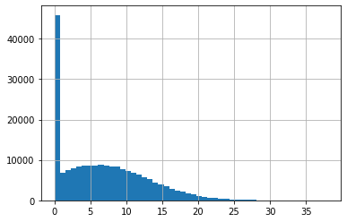

```python
df_calls['duration'].hist(bins=50)
```

```python
df_calls['duration'].describe()
```

```
count   202607.00
mean         6.76
std          5.84
min          0.00
25%          1.30
50%          6.00
75%         10.70
max         38.00
Name: duration, dtype: float64
```

Длительность звонков клиентов варьируется от 0 до 38 минут. Всреднем звонок длится 6-7 минут, 50% звонков длятся не более 10 минут и не менее 1 минуты. На гистаграмме выделяются звонки длителностью 0 минут - это пропущенные звонки, и звонки длительность более 20 минут - они очень редки.

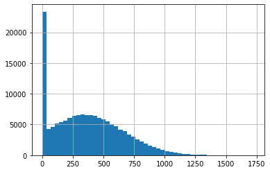

```python
df_internet['mb_used'].hist(bins=50)
```

```python
df_internet['mb_used'].describe()
```

```
count   149396.00
mean       370.19
std        278.30
min          0.00
25%        138.19
50%        348.01
75%        559.55
max       1724.83
Name: mb_used, dtype: float64
```

```python
len(df_internet[df_internet['mb_used'] == 0])/shape_internet[0]
```

```
0.13118155773916304
```

Всреднем в интернет-сессию клиент тратит 370 Мб. В данных присутствуюи сессии с нулевым расходом. Стоит обратиться к поставщику данных, в каких случаях фиксируется факт сессии без расхода трафика, или с какого объема начинается тарификация. Возможно, ошибочное открытие программы (открыл и сразу же закрыл) мы фиксируем как начало сессии, но потраченные килобайты не запоминаем, только Мб. Или это сбой тарификации. Или это бесплатные сессии (например, бесплатный доступ к соцсетям).

Если удалить нулевые значения, то мы потеряем 13% данных. При этом средняя продолжительность интернет-сессии возрастет. Оставим информацию как есть (считаем нулевые сессии бесплатными или слишком короткими для тарификации).

Посмотрим на уникальность идентификаторов.

```python
set(df_calls['user_id']).difference(df_users['user_id'])
```

```
set()
```

```python
set(df_messages['user_id']).difference(df_users['user_id'])
```

```
set()
```

```python
set(df_internet['user_id']).difference(df_users['user_id'])
```

```
set()
```

Все пользователи, представленые в таблицах по звонкам, сообщениям и интернет-трафику, имеются в таблице с портретами клиента. Данные можно объединять.

### Расчет объемов звонков, сообщений и трафика.

Посчитаем для каждого клиента:

- количество сделанных звонков и израсходованных минут разговора по месяцам;
- количество отправленных сообщений по месяцам;
- объем израсходованного интернет-трафика по месяцам.

```python
# извлечение месяца из даты
df_calls['call_month'] = df_calls['call_date'].dt.month
df_messages['message_month'] = df_messages['message_date'].dt.month
df_internet['session_month'] = df_internet['session_date'].dt.month
```

```python
# округление продолжительности звонка в большую сторону (в соответствии с правилами тарификации)
df_calls['duration'] = np.ceil(df_calls['duration']).astype(int)
```

```python
# подсчет количества звонков и их общей продолжительности по месяцам
calls = df_calls.pivot_table(index=['user_id', 'call_month'],
                     values='duration',
                     aggfunc=['count','sum'])\
    .reset_index()\
# уберем мульти-индекс
calls.columns = ['user_id','month','cnt_duration', 'sum_duration']
calls.sample(6)
```

|  | user_id | month | cnt_duration | sum_duration |
| --- | --- | --- | --- | --- |
| 644 | 1102 | 10 | 70 | 540 |
| 498 | 1079 | 9 | 86 | 603 |
| 2884 | 1454 | 12 | 67 | 514 |
| 826 | 1133 | 11 | 88 | 690 |
| 2222 | 1356 | 12 | 130 | 897 |
| 333 | 1054 | 5 | 108 | 737 |

```python
# подсчет количества смс по месяцам
messages = df_messages.pivot_table(index=['user_id', 'message_month'],
                     values='id',
                     aggfunc=['count'])\
    .reset_index()\
# уберем мульти-индекс
messages.columns = ['user_id','month','cnt_msg']
messages.sample(6)
```

|  | user_id | month | cnt_msg |
| --- | --- | --- | --- |
| 287 | 1055 | 2 | 25 |
| 2134 | 1400 | 9 | 51 |
| 25 | 1004 | 10 | 165 |
| 1161 | 1221 | 11 | 26 |
| 543 | 1098 | 12 | 14 |
| 1545 | 1299 | 9 | 45 |

```python
# подсчет объема интернет-трафика по месяцам
internet = df_internet.pivot_table(index=['user_id', 'session_month'],
                     values='mb_used',
                     aggfunc=['count', 'sum'])\
    .reset_index()

# уберем мульти-индекс
internet.columns = ['user_id','month','cnt_session', 'sum_mb']

# округлим объем трафика до целых ГБ (по правилам тарификации)
internet['sum_gb'] = np.ceil(internet['sum_mb'] / 1024)

internet.sample(6)
```

|  | user_id | month | cnt_session | sum_mb | sum_gb |
| --- | --- | --- | --- | --- | --- |
| 1777 | 1282 | 6 | 39 | 8309.89 | 9.00 |
| 2546 | 1398 | 12 | 50 | 18666.41 | 19.00 |
| 378 | 1059 | 9 | 53 | 16964.29 | 17.00 |
| 2554 | 1401 | 1 | 13 | 5144.72 | 6.00 |
| 73 | 1010 | 8 | 45 | 14463.75 | 15.00 |
| 2816 | 1437 | 10 | 56 | 18472.78 | 19.00 |

### Объединение данных.

```python
# объединяем данные о звонках, смс и трафике
users_profile = calls.merge(messages, on=['user_id','month'], how='outer')
users_profile = users_profile.merge(internet, on=['user_id','month'], how='outer')

#создаем профиль пользователя (объединяем личные данные с данными о расходах)
users_profile = df_users.merge(users_profile, on='user_id', how='left')

users_profile.info()
```

```
<class 'pandas.core.frame.DataFrame'>
Int64Index: 3216 entries, 0 to 3215
Data columns (total 15 columns):
 #   Column        Non-Null Count  Dtype
---  ------        --------------  -----
 0   user_id       3216 non-null   int64
 1   age           3216 non-null   int64
 2   churn_date    189 non-null    datetime64[ns]
 3   city          3216 non-null   object
 4   first_name    3216 non-null   object
 5   last_name     3216 non-null   object
 6   reg_date      3216 non-null   datetime64[ns]
 7   tariff        3216 non-null   object
 8   month         3214 non-null   float64
 9   cnt_duration  3174 non-null   float64
 10  sum_duration  3174 non-null   float64
 11  cnt_msg       2717 non-null   float64
 12  cnt_session   3203 non-null   float64
 13  sum_mb        3203 non-null   float64
 14  sum_gb        3203 non-null   float64
dtypes: datetime64[ns](2), float64(7), int64(2), object(4)
memory usage: 402.0+ KB
```

```python
users_profile[users_profile['month'].isnull()]
```

|  | user_id | age | churn_date | city | first_name | last_name | reg_date | tariff | month | cnt_duration | sum_duration | cnt_msg | cnt_session | sum_mb | sum_gb |
| --- | --- | --- | --- | --- | --- | --- | --- | --- | --- | --- | --- | --- | --- | --- | --- |
| 827 | 1128 | 51 | 2018-12-23 | Волжский | Ксения | Агаева | 2018-12-15 | ultra | NaN | NaN | NaN | NaN | NaN | NaN | NaN |
| 2335 | 1371 | 50 | 2018-12-30 | Омск | Ириней | Трофимов | 2018-12-25 | smart | NaN | NaN | NaN | NaN | NaN | NaN | NaN |

```python
users_profile.sample(n=5)
```

|  | user_id | age | churn_date | city | first_name | last_name | reg_date | tariff | month | cnt_duration | sum_duration | cnt_msg | cnt_session | sum_mb | sum_gb |
| --- | --- | --- | --- | --- | --- | --- | --- | --- | --- | --- | --- | --- | --- | --- | --- |
| 243 | 1039 | 40 | NaT | Ярославль | Агнесса | Андреенко | 2018-06-21 | ultra | 6.00 | 21.00 | 156.00 | 62.00 | 12.00 | 6348.47 | 7.00 |
| 1014 | 1158 | 45 | NaT | Новокузнецк | Игорь | Андрейчук | 2018-02-03 | smart | 10.00 | 62.00 | 468.00 | 62.00 | 50.00 | 15521.94 | 16.00 |
| 2782 | 1431 | 70 | NaT | Уфа | Елена | Тимофеева | 2018-03-16 | smart | 7.00 | 42.00 | 299.00 | 77.00 | 60.00 | 21506.95 | 22.00 |
| 2473 | 1386 | 21 | NaT | Новосибирск | Фаддей | Родионов | 2018-08-13 | smart | 10.00 | 64.00 | 432.00 | 43.00 | 88.00 | 24877.66 | 25.00 |
| 1562 | 1246 | 27 | NaT | Санкт-Петербург | Марта | Ситникова | 2018-09-26 | smart | 12.00 | 57.00 | 350.00 | 16.00 | 75.00 | 22003.66 | 22.00 |

При объединении данные скопированы в полном объеме: количество непустых строк объема звонков, смс и трафика соответствует размеру исходных таблиц.

Так как существуют клиенты, пользующиеся услугами частично, появились пропуски в данных. Заполним нулями отсутствующие суммарные значения потребленных услуг.

Два клиента из выборки не пользовались услугами компании, а расторгли контракты через 5-8 дней со дня регистрации. Заполним пропуски в колонке с месяцем значением месяца регистрации, чтобы посчитать доходы от абонентской платы.

```python
users_profile.columns
```

```
Index(['user_id', 'age', 'churn_date', 'city', 'first_name', 'last_name',
       'reg_date', 'tariff', 'month', 'cnt_duration', 'sum_duration',
       'cnt_msg', 'cnt_session', 'sum_mb', 'sum_gb'],
      dtype='object')
```

```python
users_profile['month'] = users_profile['month'].fillna(users_profile['reg_date'].dt.month)

users_profile[['cnt_duration', 'sum_duration',
       'cnt_msg', 'cnt_session', 'sum_mb', 'sum_gb']] = users_profile[['cnt_duration', 'sum_duration',
       'cnt_msg', 'cnt_session', 'sum_mb', 'sum_gb']].fillna(0)
```

```python
users_profile.info()
```

```
<class 'pandas.core.frame.DataFrame'>
Int64Index: 3216 entries, 0 to 3215
Data columns (total 15 columns):
 #   Column        Non-Null Count  Dtype
---  ------        --------------  -----
 0   user_id       3216 non-null   int64
 1   age           3216 non-null   int64
 2   churn_date    189 non-null    datetime64[ns]
 3   city          3216 non-null   object
 4   first_name    3216 non-null   object
 5   last_name     3216 non-null   object
 6   reg_date      3216 non-null   datetime64[ns]
 7   tariff        3216 non-null   object
 8   month         3216 non-null   float64
 9   cnt_duration  3216 non-null   float64
 10  sum_duration  3216 non-null   float64
 11  cnt_msg       3216 non-null   float64
 12  cnt_session   3216 non-null   float64
 13  sum_mb        3216 non-null   float64
 14  sum_gb        3216 non-null   float64
dtypes: datetime64[ns](2), float64(7), int64(2), object(4)
memory usage: 402.0+ KB
```

Рассчитаем помесячную выручку с каждого пользователя (вычтем бесплатный лимит из суммарного количества звонков, сообщений и интернет-трафика; остаток умножем на значение из тарифного плана; прибавем абонентскую плату, соответствующую тарифному плану).

```python
# установим наименование тарифа в качестве индекса
df_tariffs.set_index('tariff_name', inplace=True)

# определим количество предоплаченных ГБ
df_tariffs['gb_per_month_included'] = df_tariffs['mb_per_month_included'] / 1024

df_tariffs
```

| tariff_name | messages_included | mb_per_month_included | minutes_included | rub_monthly_fee | rub_per_gb | rub_per_message | rub_per_minute | gb_per_month_included |
| --- | --- | --- | --- | --- | --- | --- | --- | --- |
| smart | 50 | 15360 | 500 | 550 | 200 | 3 | 3 | 15.00 |
| ultra | 1000 | 30720 | 3000 | 1950 | 150 | 1 | 1 | 30.00 |

```python
def payment(x, service_used, service_cost, service_prepayed):
    '''Принимает на вход имя колонок в датафреймах:
    service_used - имя колонки с объемом потребленной услуги,
    service_cost - имя колонки со стоимостью услуги,
    service_prepayed - имя колонки с предоплаченным объем услуги.
    x - строка из датафрейма

    Рассчитывает разницу между предоплаченным и потребленным объемом услуги,
    превышение предоплаченного объема умножает на тариф.
'''

    return max(0, x[service_used] - df_tariffs.loc[x['tariff'], service_prepayed])\
             * df_tariffs.loc[x['tariff'],service_cost]
```

```python
# стоимость дополнительных минут
users_profile['minutes_pay'] = users_profile.apply(lambda x: payment(x,'sum_duration',\
                                                                     'rub_per_minute',\
                                                                    'minutes_included'), axis=1)

# стоимость дополнительных смс
users_profile['msg_pay'] = users_profile.apply(lambda x: payment(x,'cnt_msg',\
                                                                     'rub_per_message',\

                                                                 'messages_included'), axis=1)
# стоимость дополнительного трафика
users_profile['gb_pay'] = users_profile.apply(lambda x: payment(x,'sum_gb',\
                                                                     'rub_per_gb',\
                                                                    'gb_per_month_included'), axis=1)

# рассчитаем сумму доходов с каждого клиента
users_profile['month_pay'] = users_profile.apply(lambda x: payment(x,'sum_duration',\
                                                                     'rub_per_minute',\
                                                                    'minutes_included'), axis=1) +\
    users_profile.apply(lambda x: payment(x,'cnt_msg',\
                                            'rub_per_message',\
                                            'messages_included'), axis=1) +\
    users_profile.apply(lambda x: payment(x,'sum_gb',\
                                            'rub_per_gb',\
                                            'gb_per_month_included'), axis=1) +\
    users_profile.apply(lambda x: df_tariffs.loc[x['tariff'], 'rub_monthly_fee'], axis=1)
```

Для проверки второй гипотезы разделим клиентов на две группы: пользователи из Москвы и МО (Балашиха, Химки, Подольск), пользователи из других городов.

```python
# создаем признак Москва - Регионы
users_profile['capital'] = users_profile.apply(lambda x: x['city'] in ['Москва', 'Химки', 'Балашиха', 'Подольск'], axis=1)
```

```python
users_profile.sample(n=5)
```

|  | user_id | age | churn_date | city | first_name | last_name | reg_date | tariff | month | cnt_duration | sum_duration | cnt_msg | cnt_session | sum_mb | sum_gb | minutes_pay | msg_pay | gb_pay | month_pay | capital |
| --- | --- | --- | --- | --- | --- | --- | --- | --- | --- | --- | --- | --- | --- | --- | --- | --- | --- | --- | --- | --- |
| 2665 | 1415 | 41 | NaT | Москва | Андрей | Лукин | 2018-06-29 | ultra | 8.00 | 82.00 | 593.00 | 37.00 | 60.00 | 32715.30 | 32.00 | 0.00 | 0.00 | 300.00 | 2250.00 | True |
| 1617 | 1254 | 75 | 2018-08-17 | Москва | Александра | Сухарева | 2018-01-04 | ultra | 8.00 | 31.00 | 175.00 | 0.00 | 24.00 | 11966.72 | 12.00 | 0.00 | 0.00 | 0.00 | 1950.00 | True |
| 2373 | 1375 | 53 | NaT | Пенза | Мария | Акимычева | 2018-01-04 | ultra | 5.00 | 133.00 | 961.00 | 79.00 | 42.00 | 20299.32 | 20.00 | 0.00 | 0.00 | 0.00 | 1950.00 | False |
| 400 | 1063 | 45 | 2018-12-11 | Тула | Таира | Климова | 2018-04-12 | ultra | 12.00 | 36.00 | 231.00 | 0.00 | 11.00 | 5579.28 | 6.00 | 0.00 | 0.00 | 0.00 | 1950.00 | False |
| 456 | 1071 | 20 | 2018-08-31 | Омск | Гектор | Чумаков | 2018-01-09 | smart | 8.00 | 39.00 | 229.00 | 19.00 | 37.00 | 13950.89 | 14.00 | 0.00 | 0.00 | 0.00 | 550.00 | False |

### Выводы.

В предобработке данных мы:

1. Преобразовали даты в формат datetime.
2. Округлили продолжительность каждого звонка в большую сторону (в соответствии с правилами тарификации).
3. Округлили суммарную продолжительность интренет-сессий за месяц до Гб в большую сторону (в соответствиии с правилами тарификации).
4. Рассчитали помесячные суммарные значения для каждого клиента количества звонков и их продолжительность в минутах, количество смс, объем потраченного интернет-трафика в Гб.
5. Объединили данные в единый датафрейм. Если клиент не пользовался услугой в течении месяца, присвоили значение 0.
6. Распределили клиентов на две группы по территори проживания: Москва и МО / Регионы.
7. Посчитали суммарные ежемесячные расходы каждого клиента.

## Анализ расходов клиента.

```python
users_profile.describe()
```

|  | user_id | age | month | cnt_duration | sum_duration | cnt_msg | cnt_session | sum_mb | sum_gb | minutes_pay | msg_pay | gb_pay | month_pay |
| --- | --- | --- | --- | --- | --- | --- | --- | --- | --- | --- | --- | --- | --- |
| count | 3216.00 | 3216.00 | 3216.00 | 3216.00 | 3216.00 | 3216.00 | 3216.00 | 3216.00 | 3216.00 | 3216.00 | 3216.00 | 3216.00 | 3216.00 |
| mean | 1251.59 | 46.64 | 8.32 | 63.00 | 450.96 | 38.26 | 46.45 | 17196.91 | 17.29 | 86.51 | 12.06 | 451.10 | 1528.90 |
| std | 144.65 | 16.58 | 2.91 | 33.26 | 242.10 | 36.15 | 18.89 | 7580.75 | 7.41 | 219.17 | 34.52 | 684.02 | 798.22 |
| min | 1000.00 | 18.00 | 1.00 | 0.00 | 0.00 | 0.00 | 0.00 | 0.00 | 0.00 | 0.00 | 0.00 | 0.00 | 550.00 |
| 25% | 1125.00 | 32.00 | 6.00 | 40.00 | 282.00 | 9.00 | 35.00 | 12478.76 | 13.00 | 0.00 | 0.00 | 0.00 | 750.00 |
| 50% | 1253.00 | 46.00 | 9.00 | 62.00 | 443.00 | 30.00 | 48.00 | 16937.82 | 17.00 | 0.00 | 0.00 | 0.00 | 1653.50 |
| 75% | 1378.25 | 62.00 | 11.00 | 82.00 | 589.00 | 57.00 | 59.00 | 21422.38 | 21.00 | 0.00 | 0.00 | 800.00 | 1950.00 |
| max | 1499.00 | 75.00 | 12.00 | 244.00 | 1673.00 | 224.00 | 118.00 | 49745.69 | 49.00 | 2805.00 | 279.00 | 4600.00 | 6770.00 |

- Всреднем клиенты из выборки тратят 450 минут в месяц (среднее и медиана довольно близки - разница составляет 7 минут). 75% клиентов разговаривают менее 590 минут в месяц, менее 280 минут в месяц тратят только 25% пользователей. Существуют клиент(ы) тратящие в месяц более 1600 минут.
- Медианный расход смс 30 штук в месяц (1 шт в день). 75% аудитории отправляет до 57 смс в месяц, не более 2 в день. Максимальный расход 224 см в месяц (более 7 штук в день). 25% клиентов отправляет до 9 смс в месяц (менее 2 в неделю). Существуют клиенты, которые не пользуются смс.
- Средний расход трафика составил 17 Гб в месяц. Существуют клиенты, которые не пользуются мобильным интернетом. 75% клиентов тратят более 13 Гб интернет-трафика в месяц. 25% клиентов тратят более 21 Гб в месяц.
- 75% клиентов ежемесячно не платят за дополнительные минуты и смс. 25% клиентов платят сверх тарифа 800 рублей и более за интернет-трафик.

### В зависимости от тарифного плана.

```python
def service_analyze(column, service, measure, limit):
    '''
    Строит гистограммы использования услуги для тарифов "smart" и "ultra".

    column - Series с данными для построения гистограммы,
    service - наименование услуги (для заголовков графиков),
    measure - единица измерения услуги (для подписей оси ОХ),
    limit - наименование колонки, где хранятся данные по включенному в тариф лимиту расхода по услуге.

    '''

    # задаём размер сетки для графиков
    plt.figure(figsize=(15, 10))

    # в таблице графиков — два столбца и две строки, четыре ячейки
    # в первой строим расход услуги (например, минут разговора) клиентов тарифного плана smart
    ax1 = plt.subplot(2, 2, 1)
    users_profile.query('tariff == "smart"')[column].hist(
        bins=50, ax=ax1)

    # строим линию включенного в тариф объема услуги
    plt.axvline(df_tariffs.loc['smart', limit], color='r')

    # рассчитываем среднее, дисперсию и среднеквадритачное отклонение
    mean1 = round(users_profile.query('tariff == "smart"')[column].mean(),2)
    median1 = round(users_profile.query('tariff == "smart"')[column].median(),2)
    var1 = round(np.var(users_profile.query('tariff == "smart"')[column], ddof=1),2)
    std1 =  round(np.std(users_profile.query('tariff == "smart"')[column], ddof=1), 2)
    # отображаем их на графике
    ax1.annotate(f'Средний расход:{mean1}\nМедиана:{median1}\nДисперсия:{var1}\nСтандартное отклонение:{std1}', xy=(0.5,0.85), xycoords='axes fraction')

    # подписываем ось ОХ и наименование графика
    plt.xlabel(measure)
    plt.title(f'Расход {service} на тарифном плане smart.')


    # во второй ячейке строим расход услуги (минут разговора) клиентов тарифного плана ultra
    # вертикальная ось — от графика из первой ячейки
    ax2 = plt.subplot(2, 2, 2, sharey=ax1)
    users_profile.query('tariff == "ultra"')[column].hist(
        bins=50, ax=ax2)

    plt.axvline(df_tariffs.loc['ultra', limit], color='r')

    mean2 = round(users_profile.query('tariff == "ultra"')[column].mean(),2)
    median2 = round(users_profile.query('tariff == "ultra"')[column].median(),2)
    var2 = round(np.var(users_profile.query('tariff == "ultra"')[column], ddof=1),2)
    std2 =  round(np.std(users_profile.query('tariff == "ultra"')[column], ddof=1), 2)

    plt.xlabel(measure)
    plt.title(f'Расход {service} на тарифном плане ultra.')
    ax2.annotate(f'Средний расход:{mean2}\nМедиана:{median2}\nДисперсия:{var2}\nСтандартное отклонение:{std2}', xy=(0.5,0.85), xycoords='axes fraction')


    # в третьей ячейке строим обе гистрограммы
    ax3 = plt.subplot(2, 2, 3)
    users_profile.query('tariff == "smart"')[column].hist(
        bins=50, alpha=1, ax=ax3)
    users_profile.query('tariff == "ultra"')[column].hist(
        bins=50, alpha=0.5, ax=ax3)

    plt.xlabel(measure)
    plt.legend(['smart', 'ultra'])
    plt.title(f'Расход {service}.')

    # в четвертой ячейке строим обе гистрограммы, нормированные
    ax4 = plt.subplot(2, 2, 4)
    users_profile.query('tariff == "smart"')[column].hist(
        bins=50, alpha=1, density = True, fill=False, histtype='step', ax=ax4)
    users_profile.query('tariff == "ultra"')[column].hist(
        bins=50, alpha=0.5, density = True, fill=False, histtype='step', ax=ax4)

    plt.xlabel(measure)
    plt.legend(['smart', 'ultra'])
    plt.title(f'Расход {service}.')


    plt.grid(True)
    plt.tight_layout()
    plt.show()
```

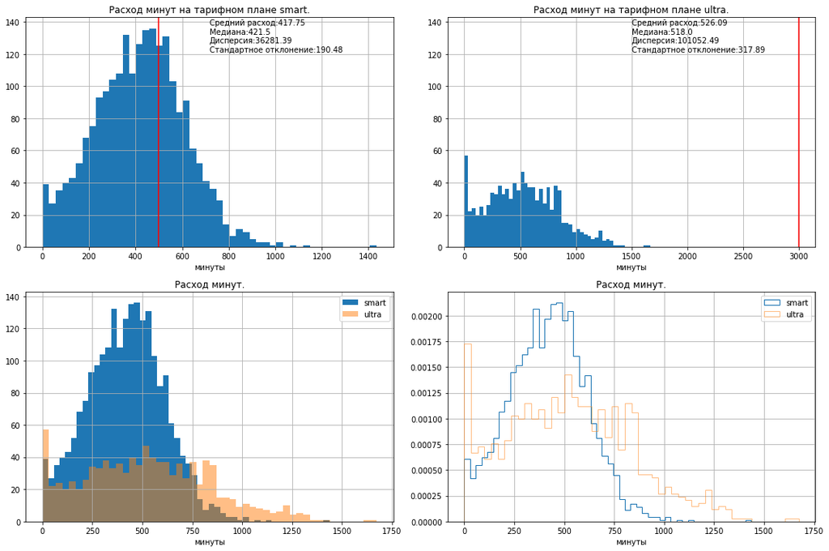

```python
service_analyze('sum_duration', 'минут', 'минуты', 'minutes_included')
```

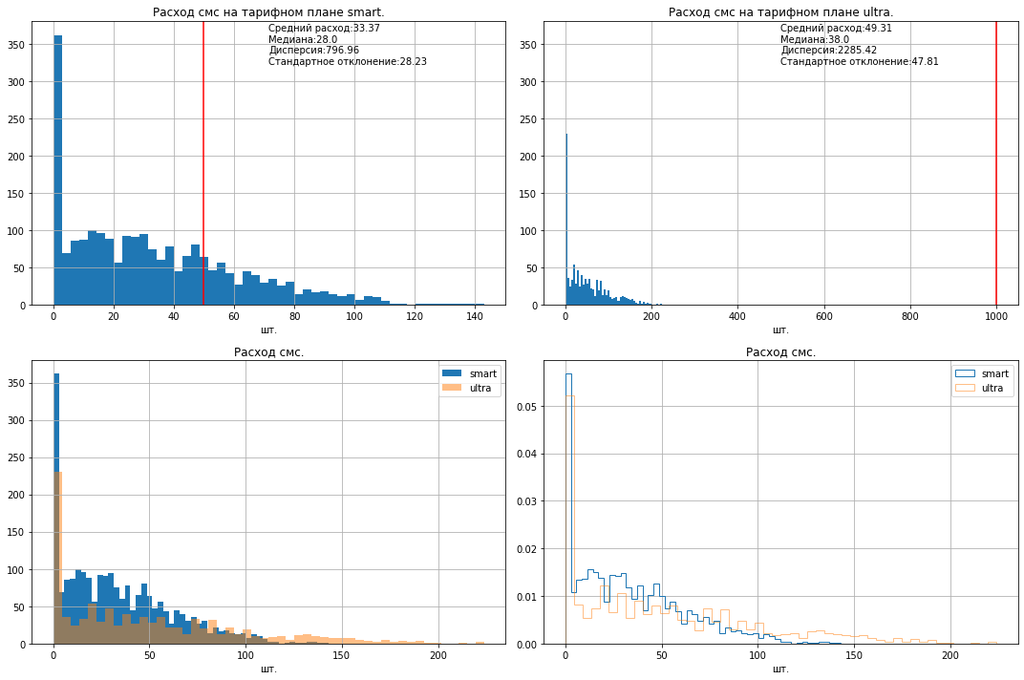

```python
service_analyze('cnt_msg', 'смс', 'шт.', 'messages_included')
```

```python
users_profile.query('tariff == "smart"')['cnt_msg'].describe()
```

```
count   2230.00
mean      33.37
std       28.23
min        0.00
25%       10.00
50%       28.00
75%       51.00
max      143.00
Name: cnt_msg, dtype: float64
```

- Распределение месячного расхода смс похоже на нормальное, с длинным хвостом вправо и большим пиком клиентов, не пользующихся данной услугой.
- Количество клиентов, не пользующихся смс, на тарифе "смарт" в 1,5 раз больше, чем на тарифе "ультра". При этом доли таких клиентов примерно одинаковые.
- Клиенты "смарт" всреднем отправляют 1 смс в день или меньше (медиана составила 28 смс, среднее 33 смс), а клиенты "ультра" больше 1 смс в день (медиана составила 38 смс, среднее - 49 смс).
- Клиенты "ультра" никогда не платят за смс сверх тарифа. 99% клиентов расходуют 20% смс включенных в тариф.
- 25% клиентов "смарт" ежемясячно платят за дополнительный расход смс.
- При расходе до 75 смс в месяц превалируют клиенты "сматр", свыше 75 смс в месяц восновном тратят клиенты "ультра". Более 150 смс в месяц тратят только клиенты "ультра".

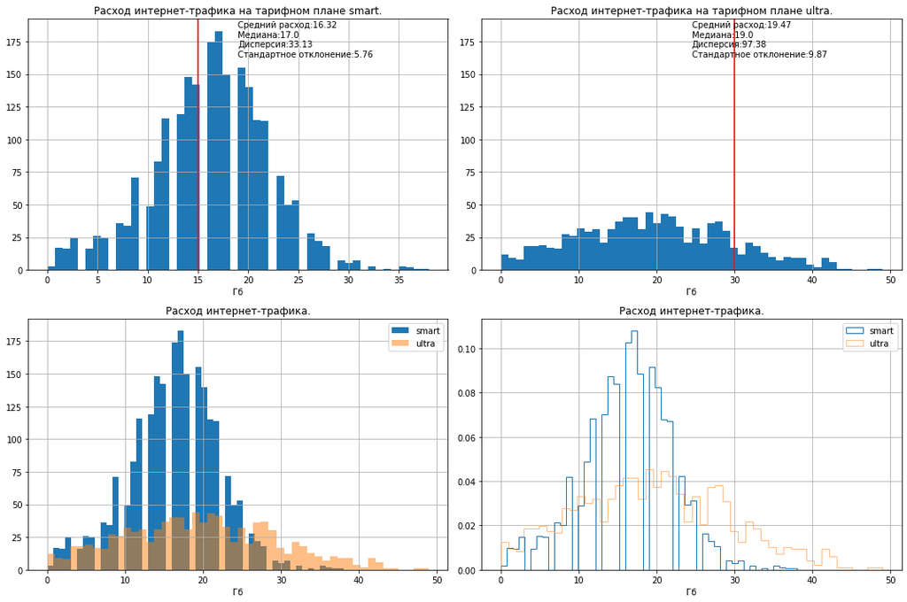

```python
service_analyze('sum_gb', 'интернет-трафика', 'Гб', 'gb_per_month_included')
```

```python
users_profile.query('tariff == "ultra"')['sum_gb'].describe()
```

```
count   986.00
mean     19.47
std       9.87
min       0.00
25%      12.00
50%      19.00
75%      27.00
max      49.00
Name: sum_gb, dtype: float64
```

```python
users_profile.query('tariff == "ultra"')['sum_gb'].quantile (.85)
```

```
30.0
```

### В зависимости от региона.

```python
def service_analyze_region(column, service, measure, limit):
    '''
    Строит гистограммы использования услуги для тарифов "smart" и "ultra"
    с разбивкой на региональную принадлежностть клиентов.

    column - Series с данными для построения гистограммы,
    service - наименование услуги (для заголовков графиков),
    measure - единица измерения услуги (для подписей оси ОХ),
    limit - наименование колонки, где хранятся данные по включенному в тариф лимиту расхода по услуге.

    '''

    # задаём размер сетки для графиков
    plt.figure(figsize=(15, 20))

    # в таблице графиков — два столбца и три строки, шесть ячеек
    # в первой строим расход минут разговора клиентов тарифного плана smart из Москвы
    ax1 = plt.subplot(3, 3, 1)
    users_profile.query('tariff == "smart" & capital == True')[column].hist(
        bins=50, ax=ax1)

    mean1 = round(users_profile.query('tariff == "smart" & capital == True')[column].mean(),2)
    median1 = round(users_profile.query('tariff == "smart" & capital == True')[column].median(),2)
    var1 = round(np.var(users_profile.query('tariff == "smart" & capital == True')[column], ddof=1),2)
    std1 =  round(np.std(users_profile.query('tariff == "smart" & capital == True')[column], ddof=1), 2)

    plt.xlabel(measure)
    plt.title(f'Расход {service} smart в Москве.')
    ax1.annotate(f'Средний расход:{mean1}\nМедиана:{median1}\nДисперсия:{var1}\nСтандартное отклонение:{std1}', xy=(0.1,0.85), xycoords='axes fraction')

    # во второй ячейке строим расход минут разговора клиентов тарифного плана smart из Регионов
    # вертикальная ось — от графика из первой ячейки
    ax2 = plt.subplot(3, 3, 2, sharey=ax1)
    users_profile.query('tariff == "smart" & capital == False')[column].hist(
        bins=50, ax=ax2)

    mean2 = round(users_profile.query('tariff == "smart" & capital == False')[column].mean(),2)
    median2 = round(users_profile.query('tariff == "smart" & capital == False')[column].median(),2)
    var2 = round(np.var(users_profile.query('tariff == "smart" & capital == False')[column], ddof=1),2)
    std2 =  round(np.std(users_profile.query('tariff == "smart" & capital == False')[column], ddof=1), 2)

    plt.xlabel(measure)
    plt.title(f'Расход {service} smart в Регионах.')
    ax2.annotate(f'Средний расход:{mean2}\nМедиана:{median2}\nДисперсия:{var2}\nСтандартное отклонение:{std2}', xy=(0.1,0.85), xycoords='axes fraction')

    #  ячейке три строим нормированный расход минут разговора клиентов тарифного плана smart
    ax3 = plt.subplot(3, 3, 3)
    users_profile.query('tariff == "smart" & capital == False')[column].hist(
        bins=50, density = True, fill=False, histtype='step', ax=ax3)
    users_profile.query('tariff == "smart" & capital == True')[column].hist(
        bins=50, density = True, fill=False, histtype='step', ax=ax3)

    plt.legend(['Regions', 'Moscow'])
    plt.xlabel(measure)
    plt.title(f'Расход {service} smart.')
    plt.axvline(df_tariffs.loc['smart', limit], color='r')

    # в четвертой ячейке строим расход минут разговора клиентов тарифного плана ultra в Москве
    ax4 = plt.subplot(3, 3, 4)
    users_profile.query('tariff == "ultra" & capital == True')[column].hist(
        bins=50, ax=ax4)

    mean3 = round(users_profile.query('tariff == "ultra" & capital == True')[column].mean(),2)
    median3 = round(users_profile.query('tariff == "ultra" & capital == True')[column].median(),2)
    var3 = round(np.var(users_profile.query('tariff == "ultra" & capital == True')[column], ddof=1),2)
    std3 =  round(np.std(users_profile.query('tariff == "ultra" & capital == True')[column], ddof=1), 2)

    plt.xlabel(measure)
    plt.title(f'Расход {service} ultra в Москве.')
    ax4.annotate(f'Средний расход:{mean3} \nМедиана: {median3}\nДисперсия: {var3}\nСтандартное отклонение: {std3}', xy=(0.1,0.85), xycoords='axes fraction')

    # в пятой ячейке строим расход минут разговора клиентов тарифного плана ultra из Регионов
    # вертикальная ось — от графика из четвертой ячейки
    ax5 = plt.subplot(3, 3, 5, sharey=ax4)
    users_profile.query('tariff == "ultra" & capital == False')[column].hist(
        bins=50, ax=ax5)

    mean4 = round(users_profile.query('tariff == "ultra" & capital == False')[column].mean(),2)
    median4 = round(users_profile.query('tariff == "ultra" & capital == False')[column].median(),2)
    var4 = round(np.var(users_profile.query('tariff == "ultra" & capital == False')[column], ddof=1),2)
    std4 =  round(np.std(users_profile.query('tariff == "ultra" & capital == False')[column], ddof=1), 2)

    plt.xlabel(measure)
    plt.title(f'Расход {service} ultra в Регионах.')
    ax5.annotate(f'Средний расход: {mean4}\nМедиана: {median4}\nДисперсия: {var4}\nСтандартное отклонение: {std4}', xy=(0.1,0.85), xycoords='axes fraction')

    #  ячейке шесть строим нормированный расход минут разговора клиентов тарифного плана ultra
    ax6 = plt.subplot(3, 3, 6)
    users_profile.query('tariff == "ultra" & capital == False')[column].hist(
        bins=50, density = True, fill=False, histtype='step', ax=ax6)
    users_profile.query('tariff == "ultra" & capital == True')[column].hist(
        bins=50, density = True, fill=False, histtype='step', ax=ax6)

    plt.legend(['Regions', 'Moscow'])
    plt.xlabel(measure)
    plt.title(f'Расход {service} ultra.')

    # в седьмой ячейке строим обе гистрограммы для клиентов из Москвы
    ax7 = plt.subplot(3, 3, 7)
    users_profile.query('tariff == "smart" & capital == True')[column].hist(
        bins=50, alpha=1, ax=ax7)
    users_profile.query('tariff == "ultra" & capital == True')[column].hist(
        bins=50, alpha=0.5, ax=ax7)

    plt.legend(['smart', 'ultra'])
    plt.xlabel(measure)
    plt.title(f'Расход {service} в Москве.')

    # в восьмой ячейке строим обе гистрограммы для клиентов из Регионов
    # вертикальная ось — от графика из седьмой ячейки
    ax8 = plt.subplot(3, 3, 8, sharey=ax7)
    users_profile.query('tariff == "smart" & capital == False')[column].hist(
        bins=50, alpha=1, ax=ax8)
    users_profile.query('tariff == "ultra" & capital == False')[column].hist(
        bins=50, alpha=0.5, ax=ax8)

    plt.legend(['smart', 'ultra'])
    plt.xlabel(measure)
    plt.title(f'Расход {service} в Регионах.')

    # в ячейке девять строим нормированный расход минут разговора клиентов
    ax9 = plt.subplot(3, 3, 9)
    users_profile.query('tariff == "smart" & capital == True')[column].hist(
        bins=50, alpha=1, density = True, fill=False, histtype='step', ax=ax9)
    users_profile.query('tariff == "ultra" & capital == True')[column].hist(
        bins=50, alpha=0.5, density = True, fill=False, histtype='step', ax=ax9)
    users_profile.query('tariff == "smart" & capital == False')[column].hist(
        bins=50, alpha=1, density = True, fill=False, histtype='step', ax=ax9)
    users_profile.query('tariff == "ultra" & capital == False')[column].hist(
        bins=50, alpha=0.5, density = True, fill=False, histtype='step', ax=ax9)

    plt.legend(['Moscow_smart','Moscow_ultra','Regions_smart', 'Regions_ultra'])
    plt.xlabel(measure)
    plt.title(f'Расход {service}.')

    plt.grid(True)
    plt.subplots_adjust(hspace=0.2)
    plt.show()
```

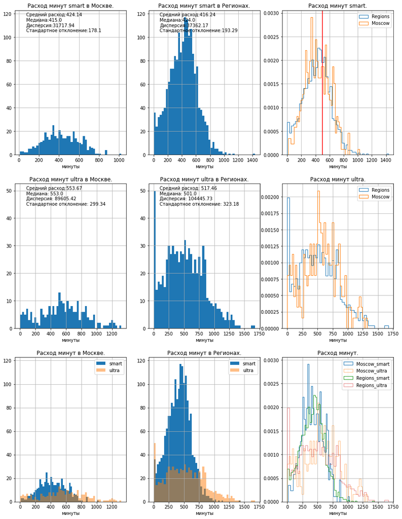

```python
service_analyze_region('sum_duration', 'минут', 'минуты', 'minutes_included')
```

- Поведение пользователей на тарифном плане "смарт" в Москве и Регионах очень похожи. Более 50% клиентов из обоих сегментов не превышают месячный лимит звонков. В Москве клиенты "смарт" не пропускаю звонков, что необычно - стоит проверить техническую сторону фиксации продолжительности звонка. Более 600 минут в месяц чаще тратят клиенты из Москвы, а более 800 - из Регионов, но их доля не велика. Средний ежемесячный расход минут клиентов "смарт" в Регионах больше чем в Москве - медиана в Москве 415, в Регионах 424 минута.
- Клиенты "ультра" в Регионах пропускают очень много звонков (по сравнению с клиентами из других сегментов). Стоит обратить внимание не техническую составляющую проблемы. Средний ежемесячный расход минут клиентов "ультра" в Регионах меньше чем в Москве - медиана в Москве 553, в Регионах 501 минута.

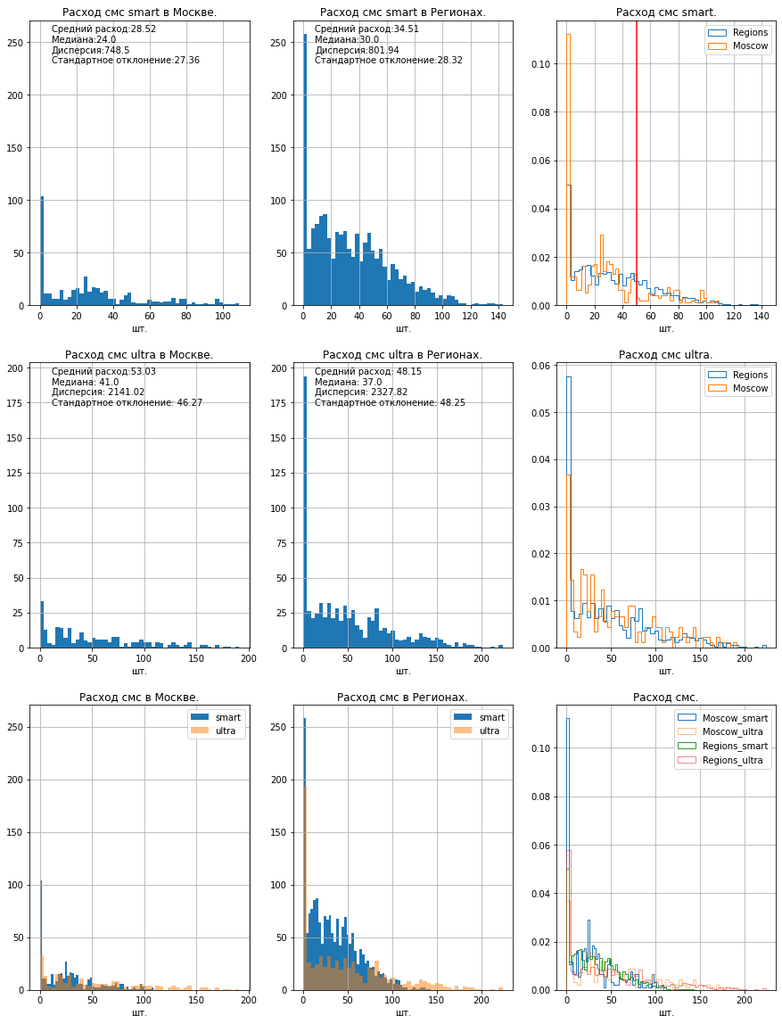

```python
service_analyze_region('cnt_msg', 'смс', 'шт.', 'messages_included')
```

```python
users_profile.query('tariff == "smart" and capital == True')['cnt_msg'].describe(percentiles=[.25,.50,.75,.81])
```

```
count   425.00
mean     28.52
std      27.36
min       0.00
25%       3.00
50%      24.00
75%      41.00
81%      50.00
max     109.00
Name: cnt_msg, dtype: float64
```

```python
users_profile.query('tariff == "smart" and capital == False')['cnt_msg'].describe(percentiles=[.25,.50,.73])
```

```
count   1805.00
mean      34.51
std       28.32
min        0.00
25%       11.00
50%       30.00
73%       50.00
max      143.00
Name: cnt_msg, dtype: float64
```

- Клиенты "смарт" в Москве чаще не пользуются смс, чем клиенты "смарт" в Регионах. А клиенты "ультра" наоборот.
- Средний расход смс на тарифе "смарт" в Москве ниже, чем в Регионах (медиана равна 24 и 30 смс соответственно). На тарифе "ультра" наоборот в Москве тратят больше, чем в Регионах (медиана равна 41 и 37 смс соответственно).
- 19% клиентов "смарт" в Москве и 27% в Регионах платят за смс сверх тарифа. На тарифе "ультра" 99% клиентов расходуют не более 200 смс в месяц (20% от лимита) и никто не платит за дополнительные смс.
- В Москве клиенты "смарт" внимательнее относятся к дополнительным расходам. После 50 смс (лимит) доля клиентов, отправляющих смс, резко снижается. В регионах такого мы не наблюдаем.

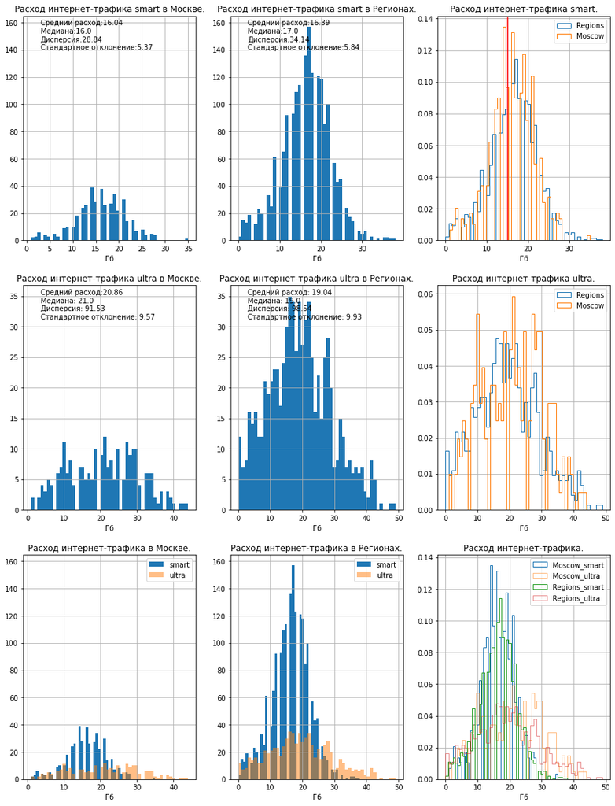

```python
service_analyze_region('sum_gb', 'интернет-трафика', 'Гб', 'gb_per_month_included')
```

```python
users_profile.query('tariff == "smart" and capital == False')['sum_gb'].describe(percentiles=[.25,.35,.50,.75])
```

```
count   1805.00
mean      16.39
std        5.84
min        0.00
25%       13.00
35%       15.00
50%       17.00
75%       20.00
max       38.00
Name: sum_gb, dtype: float64
```

```python
users_profile.query('tariff == "smart" and capital == True')['sum_gb'].describe(percentiles=[.25,.40,.50,.75])
```

```
count   425.00
mean     16.04
std       5.37
min       1.00
25%      13.00
40%      15.00
50%      16.00
75%      20.00
max      35.00
Name: sum_gb, dtype: float64
```

```python
users_profile.query('tariff == "ultra" and capital == False')['sum_gb'].describe(percentiles=[.25,.50,.75,.87])
```

```
count   751.00
mean     19.04
std       9.93
min       0.00
25%      12.00
50%      19.00
75%      26.00
87%      30.00
max      49.00
Name: sum_gb, dtype: float64
```

```python
users_profile.query('tariff == "ultra" and capital == True')['sum_gb'].describe(percentiles=[.25,.50,.75,.81])
```

```
count   235.00
mean     20.86
std       9.57
min       1.00
25%      13.00
50%      21.00
75%      28.00
81%      30.00
max      44.00
Name: sum_gb, dtype: float64
```

### Выводы:

- Все **клиенты из выборки** пользуются мобильной связью. Часть клиентов не использует мобильный интернет и/или отправку смс. Всреднем ежемесячно клиенты из выборки разговаривают 7.5 часов (450 минут), отправляют 30 смс и расходуют 17Гб интернет-трафика. 75% клиентов ежемесячно укладываются в тарифные лимиты по продолжительности звонков и смс. Одновременно существуют клиенты, разговаривающие более 26 часов в месяц. 25% клиентов ежемясячно перерасходуют включенный в тариф лимит интернет-трафика.

Минуты разговора:

- Поведение пользователей на тарифном плане "смарт" в Москве и Регионах очень похожи. Почти 50% клиентов из обоих сегментов превышают месячный лимит звонков. Среди клиентов "смарт" встречается расход минут более чем в 1,5 раза превышающий лимит. Средний ежемесячный расход минут клиентов "смарт" в Регионах больше чем в Москве на 9 минут (медиана в Москве 415 мин, в Регионах 424 минуты).
- 99% клиентов "ультра" расходуют менее 50% включенных в тариф минут. Клиенты "ультра" никогда не платят за использованные минуты разговора сверх тарифа. Средний ежемесячный расход минут клиентов "ультра" в Регионах меньше чем в Москве на 50 минут (медианное время 553 мин. против 501 мин.). Клиенты "ультра" ожидаемо чаще расходуют более 750 минут разговора в месяц.
- В Москве клиенты "смарт" не пропускаю звонков. Клиенты "ультра" в Регионах пропускают очень много звонков (по сравнению с клиентами из других сегментов). Стоит обратить внимание не техническую составляющую проблемы.

Смс:

- Количество клиентов, не пользующихся смс, на тарифе "смарт" в 1,5 раз больше, чем на тарифе "ультра". При этом доли таких клиентов примерно одинаковые. Клиенты "смарт" в Москве чаще не пользуются смс, чем клиенты "смарт" в Регионах. А клиенты "ультра" наоборот.
- Клиенты "смарт" всреднем отправляют 1 смс в день или меньше. Средний расход смс на тарифе "смарт" в Москве ниже, чем в Регионах (медиана равна 24 и 30 смс соответственно). 25% клиентов "смарт" ежемясячно платят за дополнительный расход смс (19% клиентов "смарт" в Москве и 27% в Регионах).
- Клиенты "ультра" всреднем отправляют более 1 смс в день: в Москве больше, чем в Регионах (медиана равна 41 и 37 смс соответственно). Клиенты "ультра" никогда не платят за смс сверх тарифа. 99% клиентов расходуют 20% смс включенных в тариф.
- При расходе до 75 смс в месяц превалируют клиенты "сматр", свыше 75 смс в месяц восновном тратят клиенты "ультра". Более 150 смс в месяц тратят только клиенты "ультра".
- В Москве клиенты "смарт" внимательнее относятся к дополнительным расходам. После 50 смс (лимит) доля клиентов, отправляющих смс, резко снижается. В регионах такого мы не наблюдаем.

## Анализ выручки.

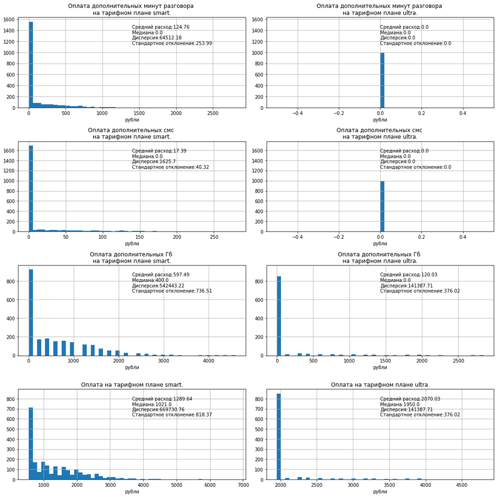

```python
# задаём размер сетки для графиков
plt.figure(figsize=(15, 15))

# в таблице графиков — два столбца и четыре строки, восемь ячеек
# в первой строим оплату минут разговора клиентами тарифного плана smart
ax1 = plt.subplot(4, 2, 1)
users_profile.query('tariff == "smart"')['minutes_pay'].hist(
        bins=50, ax=ax1)

# рассчитываем среднее, дисперсию и среднеквадритачное отклонение
mean1 = round(users_profile.query('tariff == "smart"')['minutes_pay'].mean(),2)
median1 = round(users_profile.query('tariff == "smart"')['minutes_pay'].median(),2)
var1 = round(np.var(users_profile.query('tariff == "smart"')['minutes_pay'], ddof=1),2)
std1 =  round(np.std(users_profile.query('tariff == "smart"')['minutes_pay'], ddof=1), 2)
# отображаем их на графике
ax1.annotate(f'Средний расход:{mean1}\nМедиана:{median1}\nДисперсия:{var1}\nСтандартное отклонение:{std1}', xy=(0.5,0.7), xycoords='axes fraction')

# подписываем ось ОХ и наименование графика
plt.xlabel('рубли')
plt.title(f'Оплата дополнительных минут разговора \nна тарифном плане smart.')


# во второй ячейке строим оплату минут разговора клиентами тарифного плана ultra
# вертикальная ось — от графика из первой ячейки
ax2 = plt.subplot(4, 2, 2, sharey=ax1)
users_profile.query('tariff == "ultra"')['minutes_pay'].hist(
        bins=50, ax=ax2)

# рассчитываем среднее, дисперсию и среднеквадритачное отклонение
mean2 = round(users_profile.query('tariff == "ultra"')['minutes_pay'].mean(),2)
median2 = round(users_profile.query('tariff == "ultra"')['minutes_pay'].median(),2)
var2 = round(np.var(users_profile.query('tariff == "ultra"')['minutes_pay'], ddof=1),2)
std2 =  round(np.std(users_profile.query('tariff == "ultra"')['minutes_pay'], ddof=1), 2)

plt.xlabel('рубли')
plt.title(f'Оплата дополнительных минут разговора \nна тарифном плане ultra.')
ax2.annotate(f'Средний расход:{mean2}\nМедиана:{median2}\nДисперсия:{var2}\nСтандартное отклонение:{std2}', xy=(0.5,0.7), xycoords='axes fraction')


# в третьей ячейке строим оплату смс клиентами тарифного плана smart
ax3 = plt.subplot(4, 2, 3)
users_profile.query('tariff == "smart"')['msg_pay'].hist(
        bins=50, ax=ax3)

# рассчитываем среднее, дисперсию и среднеквадритачное отклонение
mean3 = round(users_profile.query('tariff == "smart"')['msg_pay'].mean(),2)
median3 = round(users_profile.query('tariff == "smart"')['msg_pay'].median(),2)
var3 = round(np.var(users_profile.query('tariff == "smart"')['msg_pay'], ddof=1),2)
std3 =  round(np.std(users_profile.query('tariff == "smart"')['msg_pay'], ddof=1), 2)
# отображаем их на графике
ax3.annotate(f'Средний расход:{mean3}\nМедиана:{median3}\nДисперсия:{var3}\nСтандартное отклонение:{std3}', xy=(0.5,0.7), xycoords='axes fraction')

# подписываем ось ОХ и наименование графика
plt.xlabel('рубли')
plt.title(f'Оплата дополнительных смс \nна тарифном плане smart.')


# в четвертой ячейке строим оплату смс клиентами тарифного плана ultra
# вертикальная ось — от графика из третьей ячейки
ax4 = plt.subplot(4, 2, 4, sharey=ax3)
users_profile.query('tariff == "ultra"')['msg_pay'].hist(
        bins=50, ax=ax4)

# рассчитываем среднее, дисперсию и среднеквадритачное отклонение
mean4 = round(users_profile.query('tariff == "ultra"')['msg_pay'].mean(),2)
median4 = round(users_profile.query('tariff == "ultra"')['msg_pay'].median(),2)
var4 = round(np.var(users_profile.query('tariff == "ultra"')['msg_pay'], ddof=1),2)
std4 =  round(np.std(users_profile.query('tariff == "ultra"')['msg_pay'], ddof=1), 2)

plt.xlabel('рубли')
plt.title(f'Оплата дополнительных смс \nна тарифном плане ultra.')
ax4.annotate(f'Средний расход:{mean4}\nМедиана:{median4}\nДисперсия:{var4}\nСтандартное отклонение:{std4}', xy=(0.5,0.7), xycoords='axes fraction')

# в пятой ячейке строим оплату доплнительного интернет-трафика клиентами тарифного плана smart
ax5 = plt.subplot(4, 2, 5)
users_profile.query('tariff == "smart"')['gb_pay'].hist(
        bins=50, ax=ax5)

# рассчитываем среднее, дисперсию и среднеквадритачное отклонение
mean5 = round(users_profile.query('tariff == "smart"')['gb_pay'].mean(),2)
median5 = round(users_profile.query('tariff == "smart"')['gb_pay'].median(),2)
var5 = round(np.var(users_profile.query('tariff == "smart"')['gb_pay'], ddof=1),2)
std5 =  round(np.std(users_profile.query('tariff == "smart"')['gb_pay'], ddof=1), 2)
# отображаем их на графике
ax5.annotate(f'Средний расход:{mean5}\nМедиана:{median5}\nДисперсия:{var5}\nСтандартное отклонение:{std5}', xy=(0.5,0.7), xycoords='axes fraction')

# подписываем ось ОХ и наименование графика
plt.xlabel('рубли')
plt.title(f'Оплата дополнительных Гб \nна тарифном плане smart.')


# в шестой ячейке строим оплату доплнительного интернет-трафика клиентами тарифного плана ultra
# вертикальная ось — от графика из пятой ячейки
ax6 = plt.subplot(4, 2, 6, sharey=ax5)
users_profile.query('tariff == "ultra"')['gb_pay'].hist(
        bins=50, ax=ax6)

# рассчитываем среднее, дисперсию и среднеквадритачное отклонение
mean6 = round(users_profile.query('tariff == "ultra"')['gb_pay'].mean(),2)
median6 = round(users_profile.query('tariff == "ultra"')['gb_pay'].median(),2)
var6 = round(np.var(users_profile.query('tariff == "ultra"')['gb_pay'], ddof=1),2)
std6 =  round(np.std(users_profile.query('tariff == "ultra"')['gb_pay'], ddof=1), 2)

plt.xlabel('рубли')
plt.title(f'Оплата дополнительных Гб \nна тарифном плане ultra.')
ax6.annotate(f'Средний расход:{mean6}\nМедиана:{median6}\nДисперсия:{var6}\nСтандартное отклонение:{std6}', xy=(0.5,0.7), xycoords='axes fraction')

# в седьмой ячейке строим оплату  клиентами тарифного плана smart
ax7 = plt.subplot(4, 2, 7)
users_profile.query('tariff == "smart"')['month_pay'].hist(
        bins=50, ax=ax7)

# рассчитываем среднее, дисперсию и среднеквадритачное отклонение
mean7 = round(users_profile.query('tariff == "smart"')['month_pay'].mean(),2)
median7 = round(users_profile.query('tariff == "smart"')['month_pay'].median(),2)
var7 = round(np.var(users_profile.query('tariff == "smart"')['month_pay'], ddof=1),2)
std7 =  round(np.std(users_profile.query('tariff == "smart"')['month_pay'], ddof=1), 2)
# отображаем их на графике
ax7.annotate(f'Средний расход:{mean7}\nМедиана:{median7}\nДисперсия:{var7}\nСтандартное отклонение:{std7}', xy=(0.5,0.7), xycoords='axes fraction')

# подписываем ось ОХ и наименование графика
plt.xlabel('рубли')
plt.title(f'Оплата на тарифном плане smart.')


# в восьмой ячейке строим оплату клиентами тарифного плана ultra
# вертикальная ось — от графика из шестой ячейки
ax8 = plt.subplot(4, 2, 8, sharey=ax7)
users_profile.query('tariff == "ultra"')['month_pay'].hist(
        bins=50, ax=ax8)

# рассчитываем среднее, дисперсию и среднеквадритачное отклонение
mean8 = round(users_profile.query('tariff == "ultra"')['month_pay'].mean(),2)
median8 = round(users_profile.query('tariff == "ultra"')['month_pay'].median(),2)
var8 = round(np.var(users_profile.query('tariff == "ultra"')['month_pay'], ddof=1),2)
std8 =  round(np.std(users_profile.query('tariff == "ultra"')['month_pay'], ddof=1), 2)

plt.xlabel('рубли')
plt.title(f'Оплата на тарифном плане ultra.')
ax8.annotate(f'Средний расход:{mean8}\nМедиана:{median8}\nДисперсия:{var8}\nСтандартное отклонение:{std8}', xy=(0.5,0.7), xycoords='axes fraction')

plt.grid(True)
plt.tight_layout()
plt.show()
```

```python
mean8/mean7
```

```
1.6051223597282962
```

```python
users_profile.query('tariff == "smart"')['month_pay'].describe(percentiles=[.45,.80])
```

```
count   2230.00
mean    1289.64
std      818.37
min      550.00
45%      950.00
50%     1021.00
80%     1950.00
max     6770.00
Name: month_pay, dtype: float64
```

Клиенты тарифного плана "смарт" ежмесячно дополнительно платят за услуги компании: 125 рублей за минуты разговора, 18 рублей за смс и 600 рублей за интрент. Клиенты тарифного плана "ультра" дополнительно платят только за интернет, всреднем 120 рублей. Но за счет разницы в абонентской плате средний доход от клиентов "ультра" составляет 2070 рублей и превышет средний доход от клиентов "смарт" (1290 рублей) на 60,5%. Только 20% клиентов "сматр" платят сумму равную абоненсткой плате "ультра" или больше. Одновременно 45% клиентов "смарт" платят не более 950 рублей в месяц (то есть половину абонентской платы "ультра")

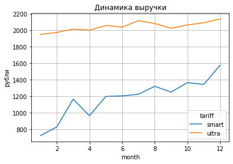

```python
users_profile.pivot_table(index='month', columns='tariff', values='month_pay').plot(kind='line',
                                                                                   grid=True,
                                                                                   title='Динамика выручки',
                                                                                   ylabel='рубли')
```

Объем выручки за 2018 год имеет тенденцию к увеличению. Причем выручка от клиентов "ультра" возросла примерно на 10%, а выручка от клиентов "смарт" более чем на 100%.

```python
# считаем оплату сверх тарифа
users_profile['pay'] = users_profile['minutes_pay'] + users_profile['msg_pay'] + users_profile['gb_pay']

# считаем оплату по тарифу
users_profile['tariff_pay'] = users_profile['month_pay'] - users_profile['pay']

# формируем таблицу доходов от клиентов в разрезе месяца начала действия контракта, месяца платежа и типа тарифа
users_pay = users_profile.groupby(['month','tariff'])\
        .agg({'pay': 'sum', 'month_pay':'sum', 'tariff_pay':'sum'})\
        .reset_index()

# считаем долю оплаты сверх тарифа и по тарифу в выручке
users_pay['%_extra_pay'] = round(users_pay['pay'] / users_pay['month_pay'] * 100, 2)
users_pay['%_tariff_pay'] = round(users_pay['tariff_pay'] / users_pay['month_pay'] * 100, 2)
```

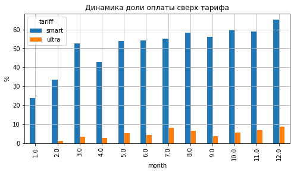

```python
# строим динамику доли оплаты сверх тарифа в доходах компании
users_pay\
    .pivot_table(index='month',
                columns=['tariff'],
                values='%_extra_pay')\
    .plot(kind='bar',
         grid=True,
         title='Динамика доли оплаты сверх тарифа',
         ylabel='%',
         figsize=(8, 4))
```

```python
users_pay.query('tariff == "smart"')['%_extra_pay'].describe()
```

```
count   12.00
mean    51.22
std     11.95
min     23.75
25%     50.30
50%     54.69
75%     58.52
max     65.09
Name: %_extra_pay, dtype: float64
```

```python
users_pay.query('tariff == "ultra"')['%_extra_pay'].describe()
```

```
count   12.00
mean     4.66
std      2.65
min      0.00
25%      3.06
50%      4.86
75%      6.49
max      8.77
Name: %_extra_pay, dtype: float64
```

Доля оплаты услуг сверх тарифа для тарифного плана "ультра" хоть и расла в течении 2018 года, но не превышает 9%. На тарифном плане "смарт" доля доходов от продажи услуг сверх тарифа за год выросла с 24 до 65%.

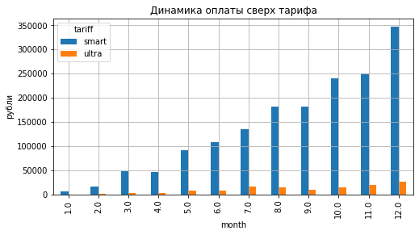

```python
# строим динамику дохода за оплату услуг сверх тарифа
users_pay\
    .pivot_table(index='month',
                columns=['tariff'],
                values='pay')\
    .plot(kind='bar',
         grid=True,
         title='Динамика оплаты сверх тарифа',
         ylabel='рубли',
         figsize=(8, 4))
```

```python
users_pay.query('tariff == "smart"')['pay'].describe()
```

```
count       12.00
mean    137450.08
std     105486.89
min       5825.00
25%      47061.00
50%     121361.50
75%     196381.25
max     346615.00
Name: pay, dtype: float64
```

```python
users_pay.query('tariff == "smart"')['pay'].max()/users_pay.query('tariff == "smart"')['pay'].min()
```

```
59.504721030042916
```

```python
users_pay.query('tariff == "ultra"')['pay'].describe()
```

```
count      12.00
mean     9862.50
std      8104.83
min         0.00
25%      2737.50
50%      8025.00
75%     14512.50
max     26250.00
Name: pay, dtype: float64
```

В абсолютных значениях выручка от оплаты дополнительных услуг на тарифе "смарт" за год выросла в 60 раз с 5800 до 346000 рублей. На тарифном плане "ультра" максимальная выручка от продажи дополнительных услуг составила 26000 рублей.

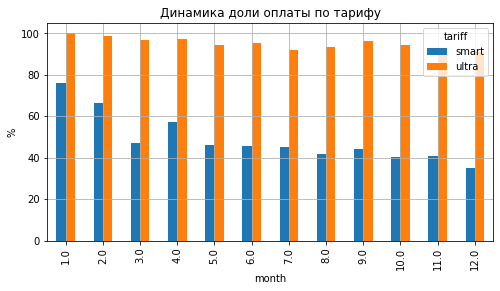

```python
# строим динамику доли оплаты по тарифу в доходах компании
users_pay\
    .pivot_table(index='month',
                columns=['tariff'],
                values='%_tariff_pay')\
    .plot(kind='bar',
         grid=True,
         title='Динамика доли оплаты по тарифу',
         ylabel='%',
         figsize=(8, 4))
```

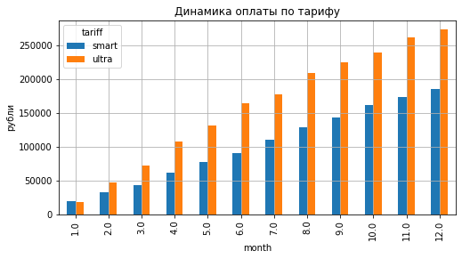

```python
# строим динамику дохода за оплату услуг по тарифу
users_pay\
    .pivot_table(index='month',
                columns=['tariff'],
                values='tariff_pay')\
    .plot(kind='bar',
         grid=True,
         title='Динамика оплаты по тарифу',
         ylabel='рубли',
         figsize=(8, 4))
```

```python
users_pay.query('tariff == "smart"')['tariff_pay'].max()/users_pay.query('tariff == "smart"')['tariff_pay'].min()
```

```
9.941176470588236
```

```python
users_pay.query('tariff == "ultra"')['tariff_pay'].max()/users_pay.query('tariff == "ultra"')['tariff_pay'].min()
```

```
15.555555555555555
```

Не смортря на то, что в выручке компании падает доля дохода от продажи тарифов, абсолютные поступления растут для обоих тарифных планов за счет роста числа клиентов. Выручка от продажи тарифов возрасла в 10 раз на тарифном плане "смарт" и в 15 раз на тарифном плане "ультра".

### Выводы.

Клиенты тарифного плана "смарт" ежмесячно дополнительно платят за услуги компании: 125 рублей за минуты разговора, 18 рублей за смс и 600 рублей за интрент. Клиенты тарифного плана "ультра" дополнительно платят только за интернет, всреднем 120 рублей. Но за счет разницы в абонентской плате средний доход от клиентов "ультра" составляет 2070 рублей и превышет средний доход от клиентов "смарт" (1290 рублей) на 60,5%. Только 20% клиентов "сматр" платят сумму равную абоненсткой плате "ультра" или больше. Одновременно 45% клиентов "смарт" платят не более 950 рублей в месяц (то есть половину абонентской платы "ультра")

Объем выручки за 2018 год имеет тенденцию к увеличению. Причем выручка от клиентов "ультра" возросла примерно на 10%, а выручка от клиентов "смарт" более чем на 100%.

Доля оплаты услуг сверх тарифа растет: для тарифного плана "ультра" не превышает 9%, на тарифном плане "смарт" выросла с 24 до 65%. В абсолютных значениях выручка от оплаты дополнительных услуг на тарифе "смарт" за год выросла в 60 раз с 5800 до 346000 рублей. На тарифном плане "ультра" максимальная выручка от продажи дополнительных услуг составила 26000 рублей.

В выручке компании падает доля дохода от продажи тарифов, но абсолютные поступления растут для обоих тарифных планов за счет роста числа клиентов. Выручка от продажи тарифов возрасла в 10 раз на тарифном плане "смарт" и в 15 раз на тарифном плане "ультра".

## Проверка гипотез.

```python
# определяем во сколько раз больше пользователей "смарт" чем пользователей "ультра"
users_profile.query('tariff == "smart"')['user_id'].nunique() / users_profile.query('tariff == "ultra"')['user_id'].nunique()
```

```
2.3557046979865772
```

```python
# определяем во сколько раз больше пользователей из Регионов чем пользователей из Москвы
users_profile.query('capital == False')['user_id'].nunique() / users_profile.query('capital == True')['user_id'].nunique()
```

```
3.7169811320754715
```

### Гипотеза 1.

Cредняя выручка пользователей тарифов «Ультра» и «Смарт» различаются.

H0: средня выручка от пользователей тарифа "Смарт" = средней выручке от пользоватлей тарифа "Ультра

Н1: средня выручка от пользователей тарифа "Смарт" != средней выручке от пользоватлей тарифа "Ультра

Количество клиентов тарифного плана "Смарт" превышает количество клиентов тарифного плана "Ультра" в 2.4 раза. Для проверки гипотезы применим статистический тест scipy.stats.ttest_ind() с дополнительным параметром equal_var = False, который используется при неравенстве объемов выборки и дисперсий.

```python
alpha = .05 # критический уровень статистической значимости
# если p-value окажется меньше него - отвергнем гипотезу

results = st.ttest_ind(
    users_profile.query('tariff == "smart"')['month_pay'],
    users_profile.query('tariff == "ultra"')['month_pay'],
    equal_var = False)

print('p-значение:', results.pvalue)
```

```
p-значение: 1.927011394420941e-250
```

Рассчитанное р-значение в много раз меньше критического уровня статистической значимости. Значит нулевую гипотезу стоит отвергнуть и принять альтернативную гипотезу.

```python
users_profile.query('tariff == "smart"')['month_pay'].describe()
```

```
count   2230.00
mean    1289.64
std      818.37
min      550.00
25%      550.00
50%     1021.00
75%     1750.00
max     6770.00
Name: month_pay, dtype: float64
```

```python
users_profile.query('tariff == "ultra"')['month_pay'].describe()
```

```
count    986.00
mean    2070.03
std      376.02
min     1950.00
25%     1950.00
50%     1950.00
75%     1950.00
max     4800.00
Name: month_pay, dtype: float64
```

### Гипотеза 2.

Средняя выручка пользователей из Москвы отличается от выручки пользователей из других регионов.

H0: средня выручка от пользователей из Москвы = средней выручке от пользоватлей из Регионов

Н1: редня выручка от пользователей из Москвы != средней выручке от пользоватлей из Регионов

Количество клиентов из Регионов в 3.7 раз превышает количество клиентов из Москвы. Для проверки гипотезы применим статистический тест scipy.stats.ttest_ind() с дополнительным параметром equal_var = False, который используется при неравенстве объемов выборки и дисперсий.

```python
alpha = .05 # критический уровень статистической значимости
# если p-value окажется меньше него - отвергнем гипотезу

results = st.ttest_ind(
    users_profile.query('capital == True')['month_pay'],
    users_profile.query('capital == False')['month_pay'],
    equal_var = False)

print('p-значение:', results.pvalue)
```

```
p-значение: 0.8553790387533635
```

Рассчитанное р-значение превышает критический уровень статистической значимости. Значит нулевую гипотезу не стоит отвергать. Существует 85.5% вероятность получить равные средние при верности нулевой гипотезы.

```python
users_profile.query('capital == True')['month_pay'].describe()
```

```
count    660.00
mean    1524.09
std      747.36
min      550.00
25%      750.00
50%     1750.00
75%     1950.00
max     5321.00
Name: month_pay, dtype: float64
```

```python
users_profile.query('capital == False')['month_pay'].describe()
```

```
count   2556.00
mean    1530.15
std      810.98
min      550.00
25%      750.00
50%     1614.00
75%     1950.00
max     6770.00
Name: month_pay, dtype: float64
```

## Общие выводы.

Мы исследовали данные о пользовании услугами федерального оператора сотовой связи "Мегалайн". В выборку попали 500 клиентов двух тарифных планов "Смарт" и "Ультра".

Данные о клиентах поступили на анализ в 4 файлах: данные о пользователях (город, возраст, тарифный план, дата регистрации и т.д.), данные о продолжительности звонков, количестве отправленных смс и потраченых Мб интернет-трафика за 2018 год.

В предобработке мы преобразовали даты в формат datetime; рассчитали помесячные суммарные значения для каждого клиента количества звонков и их продолжительность в минутах, количество смс, объем потраченного интернет-трафика в Гб (округлив значения в соответствии с правилами тарификации компании); объединили данные в единый датафрейм (если клиент не пользовался услугой в течении месяца, присвоили значение 0); распределили клиентов на две группы по территори проживания (Москва и МО / Регионы), посчитали суммарные ежемесячные расходы каждого клиента.

Все клиенты из выборки пользуются мобильной связью. Часть клиентов не использует мобильный интернет и/или отправку смс. Всреднем ежемесячно клиенты из выборки разговаривают 7.5 часов (450 минут), отправляют 30 смс и расходуют 17Гб интернет-трафика. 25% клиентов ежемесячно перерасходуют включенные в тариф лимиты по продолжительности звонков, смс и интернет-трафика. Существуют отдельные клиенты, ежемесячно разговаривающие более 20 часов, отправляющие более 200 смс, расходующие более 40 Гб интернет-трафика.

Минуты разговора:

- Поведение пользователей на тарифном плане "смарт" в Москве и Регионах очень похожи. Почти 50% клиентов из обоих сегментов превышают месячный лимит звонков. Среди клиентов "смарт" встречается расход минут более чем в 1,5 раза превышающий лимит. Средний ежемесячный расход минут клиентов "смарт" в Регионах больше чем в Москве на 9 минут (медиана в Москве 415 мин, в Регионах 424 минуты).
- 99% клиентов "ультра" расходуют менее 50% включенных в тариф минут. Клиенты "ультра" никогда не платят за использованные минуты разговора сверх тарифа. Средний ежемесячный расход минут клиентов "ультра" в Регионах меньше чем в Москве на 50 минут (медианное время 553 мин. против 501 мин.). Клиенты "ультра" ожидаемо чаще расходуют более 750 минут разговора в месяц.
- В Москве клиенты "смарт" не пропускаю звонков. Клиенты "ультра" в Регионах пропускают очень много звонков (по сравнению с клиентами из других сегментов). Стоит обратить внимание не техническую составляющую проблемы.

Смс:

- Количество клиентов, не пользующихся смс, на тарифе "смарт" в 1,5 раз больше, чем на тарифе "ультра". При этом доли таких клиентов примерно одинаковые. Клиенты "смарт" в Москве чаще не пользуются смс, чем клиенты "смарт" в Регионах. А клиенты "ультра" наоборот.
- Клиенты "смарт" всреднем отправляют 1 смс в день или меньше. Средний расход смс на тарифе "смарт" в Москве ниже, чем в Регионах (медиана равна 24 и 30 смс соответственно). 25% клиентов "смарт" ежемясячно платят за дополнительный расход смс (19% клиентов "смарт" в Москве и 27% в Регионах).
- Клиенты "ультра" всреднем отправляют более 1 смс в день: в Москве больше, чем в Регионах (медиана равна 41 и 37 смс соответственно). Клиенты "ультра" никогда не платят за смс сверх тарифа. 99% клиентов расходуют 20% смс включенных в тариф.
- При расходе до 75 смс в месяц превалируют клиенты "сматр", свыше 75 смс в месяц восновном тратят клиенты "ультра". Более 150 смс в месяц тратят только клиенты "ультра".
- В Москве клиенты "смарт" внимательнее относятся к дополнительным расходам. После 50 смс (лимит) доля клиентов, отправляющих смс, резко снижается. В регионах такого мы не наблюдаем.

Средняя выручка в Москве и регионах не различается, не смотря на то, что клиенты по-разному пользуются нашими услугами.

Статистические тесты подтвердили, что средняя выручка от клиентов "Смарт" не равна средней выручке от клиентов "Ультра". Расчеты на основе выборки показали, что средняя выручка от клиентов "Ультра" выше, чем от клиентов "Смарт" на 60%.

Клиенты тарифного плана "смарт" ежмесячно дополнительно платят за услуги компании: 125 рублей за минуты разговора, 18 рублей за смс и 600 рублей за интрент. Клиенты тарифного плана "ультра" дополнительно платят только за интернет, всреднем 120 рублей. Но за счет разницы в абонентской плате средний доход от клиентов "ультра" составляет 2070 рублей и превышет средний доход от клиентов "смарт" (1290 рублей) на 60,5%. Только 20% клиентов "сматр" платят сумму равную абоненсткой плате "ультра" или больше. Одновременно 45% клиентов "смарт" платят не более 950 рублей в месяц (то есть половину абонентской платы "ультра")

Объем выручки за 2018 год имеет тенденцию к увеличению. Причем выручка от клиентов "ультра" возросла примерно на 10%, а выручка от клиентов "смарт" более чем на 100%.

Доля оплаты услуг сверх тарифа растет: для тарифного плана "ультра" не превышает 9%, на тарифном плане "смарт" выросла с 24 до 65%. В абсолютных значениях выручка от оплаты дополнительных услуг на тарифе "смарт" за год выросла в 60 раз с 5800 до 346000 рублей. На тарифном плане "ультра" максимальная выручка от продажи дополнительных услуг составила 26000 рублей.

В выручке компании падает доля дохода от продажи тарифов, но абсолютные поступления растут для обоих тарифных планов за счет роста числа клиентов. Выручка от продажи тарифов возрасла в 10 раз на тарифном плане "смарт" и в 15 раз на тарифном плане "ультра".

**Рекомендации:** Тарифный план "смарт" уступает тарифному плану "ультра" по показателю "средний ежемесячный доход", только за счет большой разницы в абонентской плате. Пока у компании есть резервы наращивания клиентской базы за счет тарифа "ультра" стоит этим пользоваться (темп роста пока устойчивый). Тарифный план "смарт" пользуется большей популярностью и приносит доход компании за счет оплаты услуг сверх тарифа.